# Tugas Praktikum 2

# Pemanggilan *Packages*

```r
#install.packages("https://cran.r-project.org/src/contrib/Archive/orcutt/orcutt_2.1.tar.gz", repos = NULL, type = "source")
#install.packages("orcutt")
#install.packages("HoRM")
```

```r
library(dplyr)
library(readxl)
library(lmtest)   #digunakan untuk uji formal Breusch-Pagan dan Durbin-Watson
library(orcutt)   #untuk membuat model regresi Cochrane-Orcutt
library(HoRM)     #untuk membuat model regresi Hildreth-Lu
```

Kedua data diperlakukan sebagai data *cross-section* biasa, sehingga model regresi yang dibentuk adalah:

- Data 1: `Market share` sebagai peubah respon (Y), `Price` sebagai peubah bebas (X)
- Data 2: `Sales` sebagai peubah respon (Y), `Advertising` sebagai peubah bebas (X)

# BAGIAN 1: Data Market Share dan Price

## Input Data

```r
dtMS <- read_excel("C:\\Users\\najwe\\Downloads\\data_market_share_price.xlsx")
dtMS <- as.data.frame(dtMS)
names(dtMS) <- c("Period", "MarketShare", "Price")
dtMS
```

```
##    Period MarketShare Price
## 1       1        3.63  0.97
## 2       2        4.20  0.95
## 3       3        3.33  0.99
## 4       4        4.54  0.91
## 5       5        2.89  0.98
## 6       6        4.87  0.90
## 7       7        4.90  0.89
## 8       8        5.29  0.86
## 9       9        6.18  0.85
## 10     10        7.20  0.82
## 11     11        7.25  0.79
## 12     12        6.09  0.83
## 13     13        6.80  0.81
## 14     14        8.65  0.77
## 15     15        8.43  0.76
## 16     16        8.29  0.80
## 17     17        7.18  0.83
## 18     18        7.90  0.79
## 19     19        8.45  0.76
## 20     20        8.23  0.78
```

## Eksplorasi Data

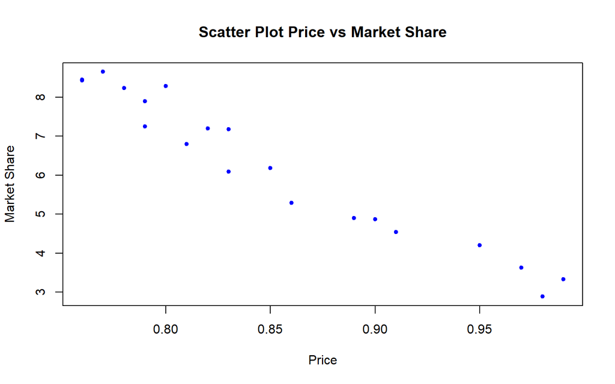

```r
#Pembuatan Scatter Plot
plot(dtMS$Price, dtMS$MarketShare, pch = 20, col = "blue",
     main = "Scatter Plot Price vs Market Share",
     xlab = "Price",
     ylab = "Market Share")
```

```r
#Menampilkan Nilai Korelasi
cor(dtMS$Price, dtMS$MarketShare)
```

```
## [1] -0.9752564
```

Berdasarkan *scatter plot* di atas, terlihat adanya hubungan / korelasi **negatif** yang kuat antara `Price` dan `Market Share`, ditunjukkan oleh titik-titik yang cenderung turun ke arah kanan bawah. Hal tersebut diperkuat oleh nilai korelasi sebesar $-0.9753$ yang menunjukkan hubungan negatif sangat kuat.

## Pemodelan Awal (Regresi OLS)

```r
model1 <- lm(MarketShare ~ Price, data = dtMS)
summary(model1)
```

```
##
## Call:
## lm(formula = MarketShare ~ Price, data = dtMS)
##
## Residuals:
##      Min       1Q   Median       3Q      Max
## -0.73068 -0.29764 -0.00966  0.30224  0.81193
##
## Coefficients:
##             Estimate Std. Error t value Pr(>|t|)
## (Intercept)   26.910      1.110   24.25 3.39e-15 ***
## Price        -24.290      1.298  -18.72 3.02e-13 ***
## ---
## Signif. codes:  0 '***' 0.001 '**' 0.01 '*' 0.05 '.' 0.1 ' ' 1
##
## Residual standard error: 0.4287 on 18 degrees of freedom
## Multiple R-squared:  0.9511, Adjusted R-squared:  0.9484
## F-statistic: 350.3 on 1 and 18 DF,  p-value: 3.019e-13
```

### Uji F

```r
summary(model1)
```

```
##
## Call:
## lm(formula = MarketShare ~ Price, data = dtMS)
##
## Residuals:
##      Min       1Q   Median       3Q      Max
## -0.73068 -0.29764 -0.00966  0.30224  0.81193
##
## Coefficients:
##             Estimate Std. Error t value Pr(>|t|)
## (Intercept)   26.910      1.110   24.25 3.39e-15 ***
## Price        -24.290      1.298  -18.72 3.02e-13 ***
## ---
## Signif. codes:  0 '***' 0.001 '**' 0.01 '*' 0.05 '.' 0.1 ' ' 1
##
## Residual standard error: 0.4287 on 18 degrees of freedom
## Multiple R-squared:  0.9511, Adjusted R-squared:  0.9484
## F-statistic: 350.3 on 1 and 18 DF,  p-value: 3.019e-13
```

```r
cat("F tabel =", qf(0.95, df1 = 1, df2 = 18))
```

```
## F tabel = 4.413873
```

Nilai $F_{hitung}$ (350.3) jauh lebih besar dari $F_{tabel}$ (4.414), sehingga H0 ditolak. Artinya, `Price` berpengaruh nyata terhadap `Market Share`.

## Uji Asumsi

### Normalitas

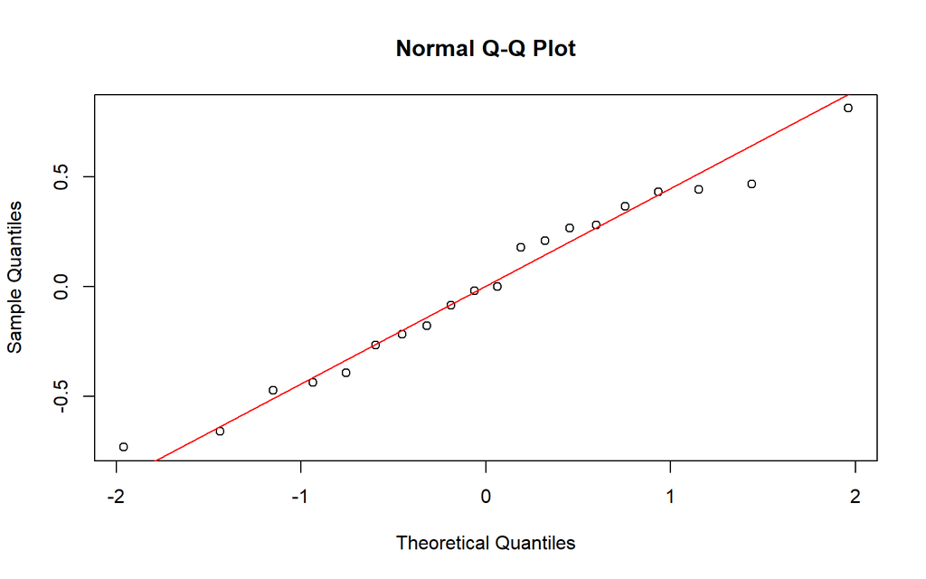

```r
qqnorm(residuals(model1))
qqline(residuals(model1), col = "red")
```

```r
shapiro.test(residuals(model1))
```

```
##
##  Shapiro-Wilk normality test
##
## data:  residuals(model1)
## W = 0.9744, p-value = 0.8437
```

*P-value* Shapiro-Wilk $> \alpha$ (5%), sehingga tak tolak H0. Cukup bukti untuk menyatakan sisaan menyebar normal.

### Homoskedastisitas

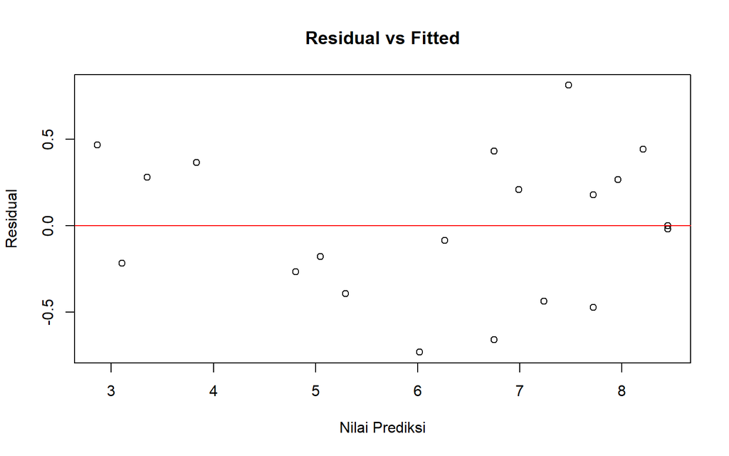

```r
plot(
  fitted(model1),
  residuals(model1),
  xlab = "Nilai Prediksi",
  ylab = "Residual",
  main = "Residual vs Fitted"
)
abline(h = 0, col = "red")
```

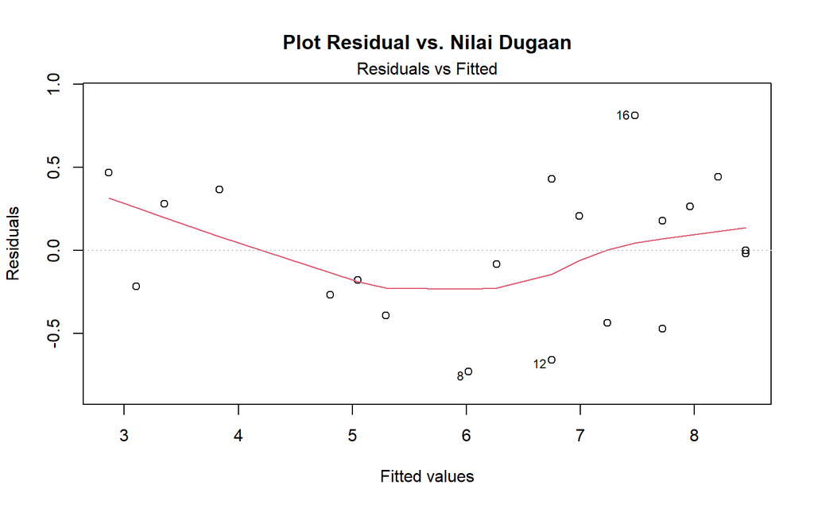

```r
plot(model1, 1,
     main = "Plot Residual vs. Nilai Dugaan",
     sub  = "")
```

```r
bptest(model1)
```

```
##
##  studentized Breusch-Pagan test
##
## data:  model1
## BP = 0.11646, df = 1, p-value = 0.7329
```

Uji Breusch-Pagan menghasilkan *p-value* $= 0.733 > \alpha$ (5%), sehingga tak tolak H0. Artinya, tidak cukup bukti menyatakan adanya heteroskedastisitas (ragam sisaan homogen).

### Sisaan Saling Bebas

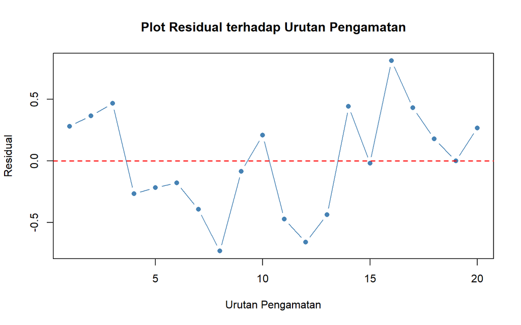

```r
plot(x    = 1:nrow(dtMS),
     y    = residuals(model1),
     type = "b",
     ylab = "Residual",
     xlab = "Urutan Pengamatan",
     main = "Plot Residual terhadap Urutan Pengamatan",
     pch  = 16,
     col  = "steelblue")
abline(h = 0, col = "red", lty = 2, lwd = 1.5)
```

Plot di atas memperlihatkan pola bergelombang (naik-turun secara berkelompok) pada sisaan menurut urutan pengamatan, mengindikasikan adanya autokorelasi.

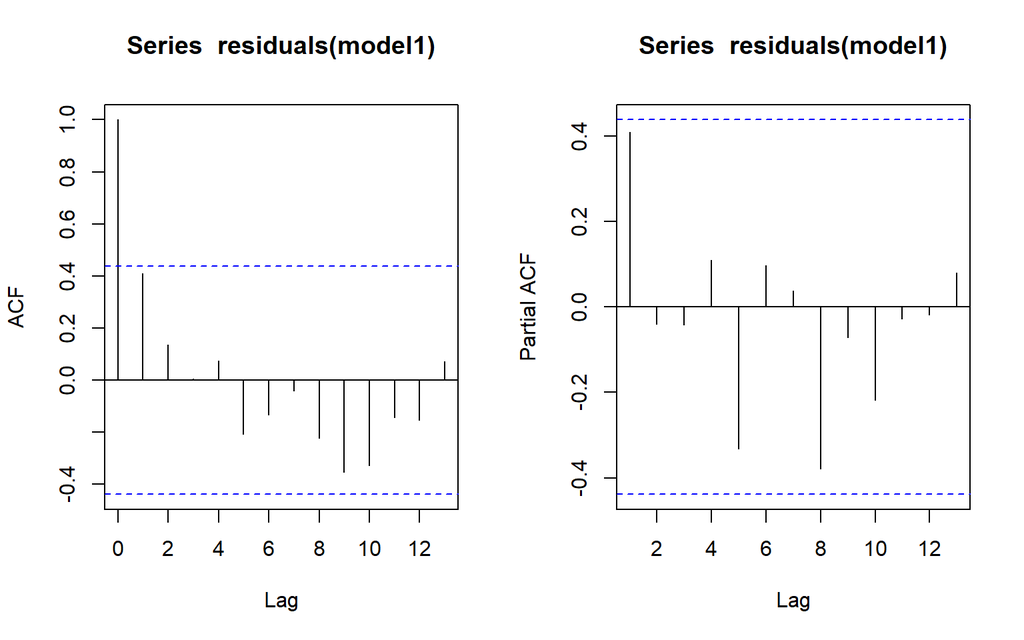

```r
#ACF dan PACF identifikasi autokorelasi
par(mfrow = c(1,2))
acf(residuals(model1))
pacf(residuals(model1))
```

```r
#Deteksi autokorelasi dengan uji-Durbin Watson
#H0: tidak ada autokorelasi
#H1: ada autokorelasi
dwtest(model1)
```

```
##
##  Durbin-Watson test
##
## data:  model1
## DW = 1.1358, p-value = 0.009813
## alternative hypothesis: true autocorrelation is greater than 0
```

Hasil uji Durbin-Watson menghasilkan nilai $DW = 1.1358$. Untuk $n=20$ dan $k=1$ peubah bebas, nilai tabel Durbin-Watson adalah $DL=1.2015$ dan $DU=1.4107$. Karena $DW (1.1358) < DL (1.2015)$ dan *p-value* $< 0.05$, maka H0 ditolak. Artinya, cukup bukti menyatakan **terdapat autokorelasi positif** pada sisaan, sehingga asumsi sisaan saling bebas **tidak terpenuhi**. Oleh karena itu diperlukan penanganan autokorelasi.

## Penanganan Autokorelasi

Karena asumsi sisaan saling bebas tidak terpenuhi (terdeteksi autokorelasi positif), dilakukan penanganan dengan dua metode: Cochrane-Orcutt dan Hildreth-Lu.

### Metode Cochrane-Orcutt

Penanganan metode Cochrane-Orcutt dapat dilakukan dengan bantuan packages Orcutt pada aplikasi `R` maupun secara manual. Berikut ini ditampilkan cara menggunakan bantuan `library` *packages* `Orcutt`.

```r
modelCO1 <- cochrane.orcutt(model1)
modelCO1
```

```
## Cochrane-orcutt estimation for first order autocorrelation
##
## Call:
## lm(formula = MarketShare ~ Price, data = dtMS)
##
##  number of interaction: 8
##  rho 0.425232
##
## Durbin-Watson statistic
## (original):    1.13582 , p-value: 9.813e-03
## (transformed): 1.95804 , p-value: 4.151e-01
##
##  coefficients:
## (Intercept)       Price
##    26.72209   -24.08413
```

Hasil model setelah penanganan Cochrane-Orcutt adalah
$$\hat{y}_i = 26.72209-24.08413x_t$$
dengan nilai DW meningkat menjadi sekitar $1.958$ dan *p-value* $> 0.05$. Nilai DW berada pada rentang $DU < DW < 4-DU$ ($1.4107 < 1.958 < 2.59$), artinya tidak cukup bukti menyatakan sisaan masih terdapat autokorelasi pada taraf nyata 5%. Nilai $\hat\rho$ optimum yang digunakan adalah sekitar $0.4252$.

```r
#Rho optimum
rho1 <- modelCO1$rho
rho1
```

```
## [1] 0.4252321
```

```r
#Transformasi Manual
n1 <- nrow(dtMS)
ms.trans <- dtMS$MarketShare[-1] - dtMS$MarketShare[-n1]*rho1
price.trans <- dtMS$Price[-1] - dtMS$Price[-n1]*rho1
modelCO1manual <- lm(ms.trans ~ price.trans)
summary(modelCO1manual)
```

```
##
## Call:
## lm(formula = ms.trans ~ price.trans)
##
## Residuals:
##      Min       1Q   Median       3Q      Max
## -0.55508 -0.25069 -0.05506  0.25007  0.83017
##
## Coefficients:
##             Estimate Std. Error t value Pr(>|t|)
## (Intercept)  15.3590     0.9385   16.36 7.71e-12 ***
## price.trans -24.0841     1.9385  -12.42 5.90e-10 ***
## ---
## Signif. codes:  0 '***' 0.001 '**' 0.01 '*' 0.05 '.' 0.1 ' ' 1
##
## Residual standard error: 0.3955 on 17 degrees of freedom
## Multiple R-squared:  0.9008, Adjusted R-squared:  0.895
## F-statistic: 154.4 on 1 and 17 DF,  p-value: 5.903e-10
```

```r
#Mencari Penduga Koefisien Regresi setelah Transformasi ke Persamaan Awal
b0bintang1 <- modelCO1manual$coefficients[-2]
b0.1 <- b0bintang1/(1-rho1)
b1.1 <- modelCO1manual$coefficients[-1]
b0.1
```

```
## (Intercept)
##    26.72209
```

```r
b1.1
```

```
## price.trans
##   -24.08413
```

Hasil perhitungan koefisien regresi manual sama dengan hasil dari *packages* `orcutt`.

### Metode Hildreth-Lu

Penanganan kedua adalah menggunakan metode Hildreth-Lu. Metode ini akan mencari nilai SSE terkecil dan dapat dicari secara manual maupun menggunakan packages. Jika menggunakan packages, gunakan `library` *packages* `HoRM`.

```r
library(HoRM)

# ambil y dan x (satu prediktor)
y1 <- dtMS$MarketShare
x1 <- dtMS$Price

# grid search rho 0–0.9
r <- seq(0, 0.9, by = 0.1)
tab1a <- data.frame(
  rho = r,
  SSE = sapply(r, function(rr) deviance(hildreth.lu(y1, x1, rr)))
)

tab1a            # tabel rho vs SSE
```

```
##    rho      SSE
## 1  0.0 3.212112
## 2  0.1 2.979074
## 3  0.2 2.810498
## 4  0.3 2.705239
## 5  0.4 2.661188
## 6  0.5 2.674924
## 7  0.6 2.741983
## 8  0.7 2.858804
## 9  0.8 3.026489
## 10 0.9 3.252863
```

```r
rho_hat1 <- tab1a$rho[which.min(tab1a$SSE)]   # rho terbaik
fit_hl1  <- hildreth.lu(y1, x1, rho_hat1)     # model final
summary(fit_hl1)
```

```
##
## Call:
## lm(formula = y ~ x)
##
## Residuals:
##      Min       1Q   Median       3Q      Max
## -0.56476 -0.24781 -0.05422  0.25392  0.82998
##
## Coefficients:
##             Estimate Std. Error t value Pr(>|t|)
## (Intercept)   16.070      0.957   16.79 5.10e-12 ***
## x            -24.158      1.892  -12.77 3.88e-10 ***
## ---
## Signif. codes:  0 '***' 0.001 '**' 0.01 '*' 0.05 '.' 0.1 ' ' 1
##
## Residual standard error: 0.3957 on 17 degrees of freedom
## Multiple R-squared:  0.9055, Adjusted R-squared:    0.9
## F-statistic:   163 on 1 and 17 DF,  p-value: 3.88e-10
```

```r
#Penanganan Autokorelasi Hildreth lu
hildreth.lu.func <- function(r, model){
  x <- model.matrix(model)[,-1]
  y <- model.response(model.frame(model))
  n <- length(y)
  t <- 2:n
  y <- y[t]-r*y[t-1]
  x <- x[t]-r*x[t-1]
  return(lm(y~x))
}

#Pencarian rho optimum
r <- c(seq(0,0.9, by= 0.1))
tab1 <- data.frame("rho" = r, "SSE" = sapply(r, function(i){deviance(hildreth.lu.func(i, model1))}))
round(tab1, 4)
```

```
##    rho    SSE
## 1  0.0 3.2121
## 2  0.1 2.9791
## 3  0.2 2.8105
## 4  0.3 2.7052
## 5  0.4 2.6612
## 6  0.5 2.6749
## 7  0.6 2.7420
## 8  0.7 2.8588
## 9  0.8 3.0265
## 10 0.9 3.2529
```

SSE minimum terlihat di sekitar $\rho=0.4$. Selanjutnya dicari $\rho$ yang lebih optimum dengan ketelitian lebih tinggi.

```r
#Rho optimal di sekitar 0.4
rOpt1 <- seq(0.3,0.5, by= 0.001)
tabOpt1 <- data.frame("rho" = rOpt1, "SSE" = sapply(rOpt1, function(i){deviance(hildreth.lu.func(i, model1))}))
head(tabOpt1[order(tabOpt1$SSE),])
```

```
##       rho      SSE
## 126 0.425 2.659368
## 127 0.426 2.659370
## 125 0.424 2.659372
## 128 0.427 2.659377
## 124 0.423 2.659382
## 129 0.428 2.659390
```

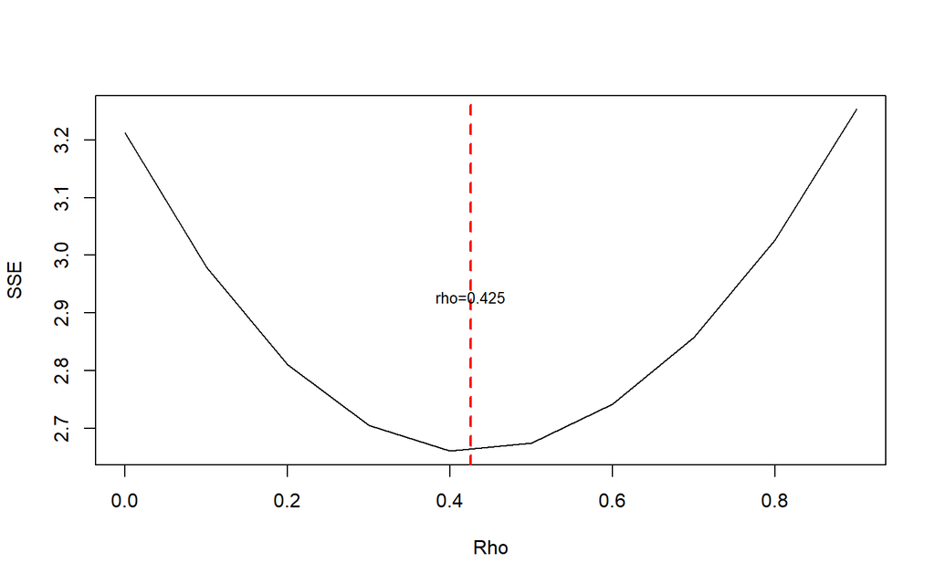

```r
#Grafik SSE optimum
par(mfrow = c(1,1))
plot(tab1$SSE ~ tab1$rho , type = "l", xlab = "Rho", ylab = "SSE")
abline(v = 0.425, lty = 2, col="red", lwd=2)
text(x=0.425, y=max(tab1$SSE)*0.9, labels = "rho=0.425", cex = 0.8)
```

Nilai $\rho$ optimum (SSE terkecil) adalah $\rho=0.425$.

```r
#Model terbaik
modelHL1 <- hildreth.lu.func(0.425, model1)
summary(modelHL1)
```

```
##
## Call:
## lm(formula = y ~ x)
##
## Residuals:
##      Min       1Q   Median       3Q      Max
## -0.55517 -0.25066 -0.05505  0.25010  0.83017
##
## Coefficients:
##             Estimate Std. Error t value Pr(>|t|)
## (Intercept)  15.3655     0.9387   16.37 7.68e-12 ***
## x           -24.0848     1.9380  -12.43 5.88e-10 ***
## ---
## Signif. codes:  0 '***' 0.001 '**' 0.01 '*' 0.05 '.' 0.1 ' ' 1
##
## Residual standard error: 0.3955 on 17 degrees of freedom
## Multiple R-squared:  0.9008, Adjusted R-squared:  0.895
## F-statistic: 154.4 on 1 and 17 DF,  p-value: 5.88e-10
```

```r
#Transformasi Balik
cat("y = ", coef(modelHL1)[1]/(1-0.425), "+", coef(modelHL1)[2], "x", sep = "")
```

```
## y = 26.72268+-24.08484x
```

Model hasil metode Hildreth-Lu adalah
$$\hat{y}_i = 26.7227-24.0848x_t$$

```r
#Deteksi autokorelasi
dwtest(modelHL1)
```

```
##
##  Durbin-Watson test
##
## data:  modelHL1
## DW = 1.9577, p-value = 0.4148
## alternative hypothesis: true autocorrelation is greater than 0
```

Nilai DW hasil metode Hildreth-Lu adalah sekitar $1.9577$, berada pada rentang $DU < DW < 4-DU$ dengan *p-value* $> 0.05$. Tidak cukup bukti menyatakan adanya autokorelasi setelah penanganan.

### Perbandingan SSE

```r
sseModelawal1 <- anova(model1)$`Sum Sq`[-1]
sseModelCO1 <- anova(modelCO1manual)$`Sum Sq`[-1]
sseModelHL1 <- anova(modelHL1)$`Sum Sq`[-1]
akurasi1 <- matrix(c(sseModelawal1, sseModelCO1, sseModelHL1), nrow = 1)
colnames(akurasi1) <- c("Model Awal", "Model Cochrane-Orcutt", "Model Hildreth-Lu")
row.names(akurasi1) <- "SSE"
akurasi1
```

```
##     Model Awal Model Cochrane-Orcutt Model Hildreth-Lu
## SSE   3.308257              2.659368          2.659368
```

SSE model awal ($\approx 3.31$) lebih besar dibandingkan SSE model setelah penanganan CO maupun HL ($\approx 2.66$), menunjukkan kedua metode berhasil memperbaiki model.

Jika dibandingkan antara kedua metode penanganan itu sendiri, SSE model Cochrane-Orcutt dan Hildreth-Lu bernilai sangat berdekatan (selisih hampir tidak terlihat), sejalan dengan nilai $\hat\rho$ optimum yang juga hampir sama antara keduanya (Cochrane-Orcutt: $\hat\rho \approx 0.4252$ dan Hildreth-Lu: $\hat\rho = 0.425$). Hal ini menunjukkan bahwa untuk data `Market Share-Price`, kedua metode sama-sama efektif dan konsisten dalam menemukan titik $\rho$ yang meminimumkan SSE, sehingga tidak terdapat perbedaan praktis yang berarti antara memilih salah satu dari kedua metode tersebut.

# BAGIAN 2: Data Sales dan Advertising

## Input Data

```r
dtSA <- read_excel("C:\\Users\\najwe\\Downloads\\data_sales_advertising_1975_2014.xlsx")
dtSA <- as.data.frame(dtSA)
names(dtSA) <- c("Year", "Sales", "Advertising")
head(dtSA)
```

```
##   Year Sales Advertising
## 1 1975  11.7         9.4
## 2 1976  12.0         9.6
## 3 1977  12.3        10.0
## 4 1978  12.8        10.4
## 5 1979  13.1        10.8
## 6 1980  13.6        10.9
```

## Eksplorasi Data

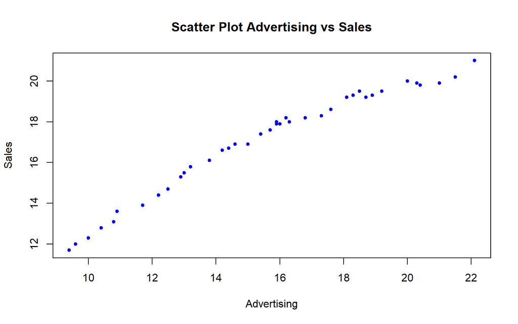

```r
plot(dtSA$Advertising, dtSA$Sales, pch = 20, col = "blue",
     main = "Scatter Plot Advertising vs Sales",
     xlab = "Advertising",
     ylab = "Sales")
```

```r
cor(dtSA$Advertising, dtSA$Sales)
```

```
## [1] 0.9795849
```

*Scatter plot* menunjukkan hubungan / korelasi **positif** yang sangat kuat antara `Advertising` dan `Sales` (korelasi $= 0.9796$).

## Pemodelan Awal (Regresi OLS)

```r
model2 <- lm(Sales ~ Advertising, data = dtSA)
summary(model2)
```

```
##
## Call:
## lm(formula = Sales ~ Advertising, data = dtSA)
##
## Residuals:
##      Min       1Q   Median       3Q      Max
## -1.03758 -0.40343  0.08933  0.45674  0.74036
##
## Coefficients:
##             Estimate Std. Error t value Pr(>|t|)
## (Intercept)  5.96513    0.38092   15.66   <2e-16 ***
## Advertising  0.71035    0.02365   30.04   <2e-16 ***
## ---
## Signif. codes:  0 '***' 0.001 '**' 0.01 '*' 0.05 '.' 0.1 ' ' 1
##
## Residual standard error: 0.527 on 38 degrees of freedom
## Multiple R-squared:  0.9596, Adjusted R-squared:  0.9585
## F-statistic: 902.3 on 1 and 38 DF,  p-value: < 2.2e-16
```

Model regresi yang dihasilkan adalah
$$\hat{y}_i = 5.9651+0.7103x_t$$
dengan nilai $R^2$ sebesar 0.95 yang berarti bahwa sebesar 95% variasi pada variabel $Y$ dapat dijelaskan oleh variabel $X$.

### Uji F

```r
summary(model2)
```

```
##
## Call:
## lm(formula = Sales ~ Advertising, data = dtSA)
##
## Residuals:
##      Min       1Q   Median       3Q      Max
## -1.03758 -0.40343  0.08933  0.45674  0.74036
##
## Coefficients:
##             Estimate Std. Error t value Pr(>|t|)
## (Intercept)  5.96513    0.38092   15.66   <2e-16 ***
## Advertising  0.71035    0.02365   30.04   <2e-16 ***
## ---
## Signif. codes:  0 '***' 0.001 '**' 0.01 '*' 0.05 '.' 0.1 ' ' 1
##
## Residual standard error: 0.527 on 38 degrees of freedom
## Multiple R-squared:  0.9596, Adjusted R-squared:  0.9585
## F-statistic: 902.3 on 1 and 38 DF,  p-value: < 2.2e-16
```

```r
cat("F tabel =", qf(0.95, df1 = 1, df2 = 38))
```

```
## F tabel = 4.098172
```

$F_{hitung}$ (902.3) $> F_{tabel}$ (4.098), sehingga H0 ditolak; `Advertising` berpengaruh nyata terhadap `Sales`.

## Uji Asumsi

### Normalitas

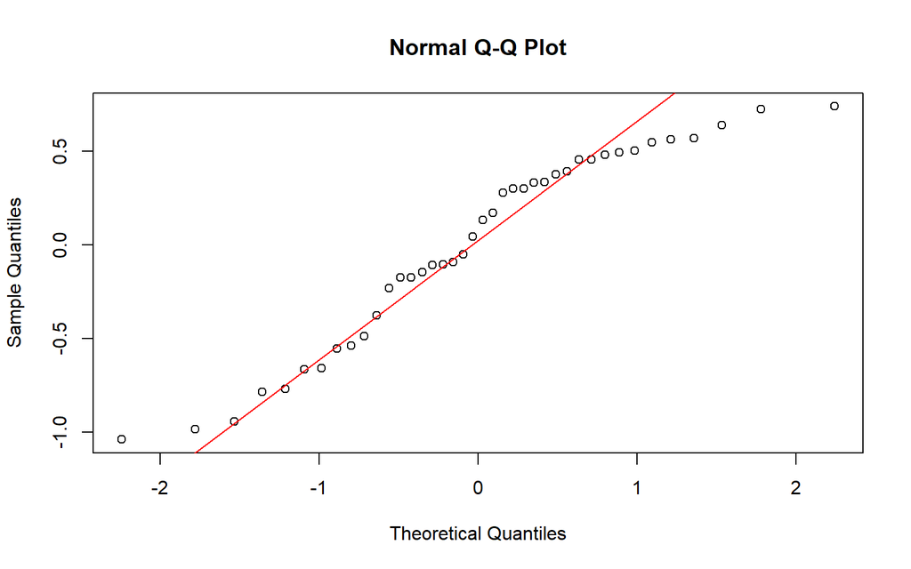

```r
qqnorm(residuals(model2))
qqline(residuals(model2), col = "red")
```

```r
shapiro.test(residuals(model2))
```

```
##
##  Shapiro-Wilk normality test
##
## data:  residuals(model2)
## W = 0.93205, p-value = 0.0188
```

Berdasarkan uji Shapiro-Wilk diperoleh **p-value = 0,0188 < 0,05**, sehingga H₀ ditolak. Artinya, **residual model 12 tidak berdistribusi normal**, sehingga asumsi normalitas residual belum terpenuhi. **Namun, karena fokus analisis kali ini adalah penanganan autokorelasi, asumsi kenormalan tidak ditangani lebih lanjut.**

### Homoskedastisitas

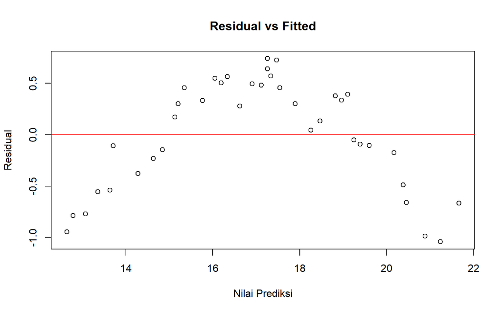

```r
plot(
  fitted(model2),
  residuals(model2),
  xlab = "Nilai Prediksi",
  ylab = "Residual",
  main = "Residual vs Fitted"
)
abline(h = 0, col = "red")
```

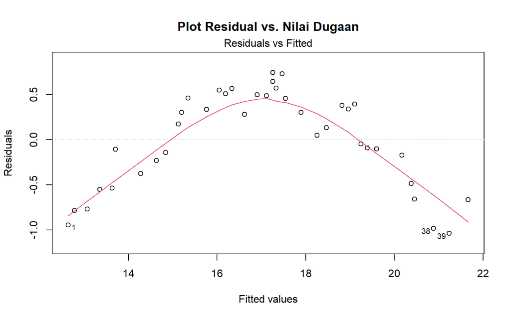

```r
plot(model2, 1,
     main = "Plot Residual vs. Nilai Dugaan",
     sub  = "")
```

```r
bptest(model2)
```

```
##
##  studentized Breusch-Pagan test
##
## data:  model2
## BP = 0.0037386, df = 1, p-value = 0.9512
```

Uji Breusch-Pagan menghasilkan *p-value* $= 0.951 > \alpha$ (5%), sehingga tak tolak H0. Tidak cukup bukti adanya heteroskedastisitas.

### Sisaan Saling Bebas

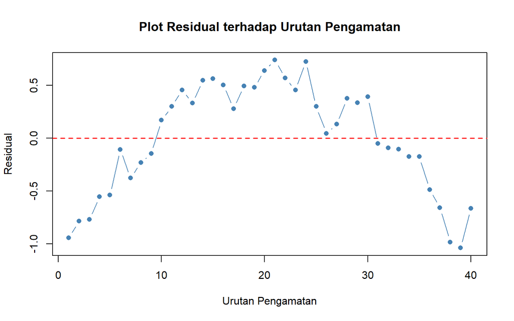

```r
plot(x    = 1:nrow(dtSA),
     y    = residuals(model2),
     type = "b",
     ylab = "Residual",
     xlab = "Urutan Pengamatan",
     main = "Plot Residual terhadap Urutan Pengamatan",
     pch  = 16,
     col  = "steelblue")
abline(h = 0, col = "red", lty = 2, lwd = 1.5)
```

Plot memperlihatkan pola yang jelas (sisaan bergerak searah pada rentang waktu yang berdekatan), mengindikasikan autokorelasi kuat.

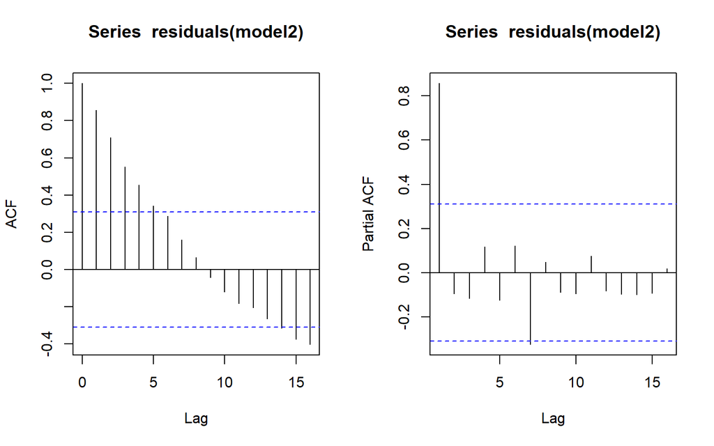

```r
#ACF dan PACF identifikasi autokorelasi
par(mfrow = c(1,2))
acf(residuals(model2))
pacf(residuals(model2))
```

Plot ACF memperlihatkan lag-lag awal yang keluar dari batas signifikansi, mengindikasikan adanya autokorelasi positif yang kuat pada sisaan. Untuk memastikan hal ini akan dilakukan uji formal dengan uji Durbin-Watson.

```r
#Deteksi autokorelasi dengan uji-Durbin Watson
#H0: tidak ada autokorelasi
#H1: ada autokorelasi
dwtest(model2)
```

```
##
##  Durbin-Watson test
##
## data:  model2
## DW = 0.16204, p-value < 2.2e-16
## alternative hypothesis: true autocorrelation is greater than 0
```

Nilai $DW = 0.1620$. Untuk $n=40$ dan $k=1$, nilai tabel Durbin-Watson adalah $DL=1.4421$ dan $DU=1.5444$. Karena $DW (0.1620) < DL (1.4421)$ dan *p-value* jauh $< 0.05$, H0 ditolak sehingga terdapat autokorelasi positif yang kuat. Asumsi sisaan saling bebas **tidak terpenuhi**, wajar mengingat data bersifat deret waktu tahunan yang memiliki kelembaman. Diperlukan penanganan autokorelasi.

## Penanganan Autokorelasi

### Metode Cochrane-Orcutt

Penanganan metode Cochrane-Orcutt dapat dilakukan dengan bantuan packages Orcutt pada aplikasi `R` maupun secara manual. Berikut ini ditampilkan cara menggunakan bantuan `library` *packages* `Orcutt`.

```r
modelCO2 <- cochrane.orcutt(model2)
modelCO2
```

```
## Cochrane-orcutt estimation for first order autocorrelation
##
## Call:
## lm(formula = Sales ~ Advertising, data = dtSA)
##
##  number of interaction: 39
##  rho 0.903123
##
## Durbin-Watson statistic
## (original):    0.16204 , p-value: 8.935e-20
## (transformed): 1.93925 , p-value: 3.78e-01
##
##  coefficients:
## (Intercept) Advertising
##   10.252375    0.488489
```

Model setelah penanganan:
$$\hat{y}_i =
10.2524+0.4885x_t$$
dengan DW meningkat tajam menjadi sekitar $1.939$ ($DU < DW < 4-DU$: $1.54 < 1.939 < 2.46$), *p-value* $>0.05$. Nilai $\hat\rho$ optimum $\approx 0.9031$ (kelembaman tinggi pada data tahunan).

```r
#Rho optimum
rho2 <- modelCO2$rho
rho2
```

```
## [1] 0.9031233
```

```r
#Transformasi Manual
n2 <- nrow(dtSA)
sales.trans <- dtSA$Sales[-1] - dtSA$Sales[-n2]*rho2
adv.trans <- dtSA$Advertising[-1] - dtSA$Advertising[-n2]*rho2
modelCO2manual <- lm(sales.trans ~ adv.trans)
summary(modelCO2manual)
```

```
##
## Call:
## lm(formula = sales.trans ~ adv.trans)
##
## Residuals:
##      Min       1Q   Median       3Q      Max
## -0.37730 -0.14957  0.01257  0.10464  0.45315
##
## Coefficients:
##             Estimate Std. Error t value Pr(>|t|)
## (Intercept)  0.99322    0.14141   7.023 2.64e-08 ***
## adv.trans    0.48849    0.07543   6.476 1.43e-07 ***
## ---
## Signif. codes:  0 '***' 0.001 '**' 0.01 '*' 0.05 '.' 0.1 ' ' 1
##
## Residual standard error: 0.1868 on 37 degrees of freedom
## Multiple R-squared:  0.5313, Adjusted R-squared:  0.5186
## F-statistic: 41.94 on 1 and 37 DF,  p-value: 1.426e-07
```

```r
#Mencari Penduga Koefisien Regresi setelah Transformasi ke Persamaan Awal
b0bintang2 <- modelCO2manual$coefficients[-2]
b0.2 <- b0bintang2/(1-rho2)
b1.2 <- modelCO2manual$coefficients[-1]
b0.2
```

```
## (Intercept)
##    10.25237
```

```r
b1.2
```

```
## adv.trans
## 0.4884891
```

Hasil perhitungan koefisien regresi manual ($\hat\beta_0 \approx 10.2524$ dan $\hat\beta_1 \approx 0.4885$) sama dengan hasil dari *packages* `orcutt`, sehingga transformasi dan perhitungan yang dilakukan sudah tepat.

### Metode Hildreth-Lu

Penanganan kedua adalah menggunakan metode Hildreth-Lu. Metode ini akan mencari nilai SSE terkecil dan dapat dicari secara manual maupun menggunakan packages. Jika menggunakan packages, gunakan `library` *packages* `HoRM`.

```r
library(HoRM)

# ambil y dan x (satu prediktor saja)
y2 <- dtSA$Sales
x2 <- dtSA$Advertising

# grid search rho 0–0.9
r <- seq(0, 0.9, by = 0.1)
tab2a <- data.frame(
  rho = r,
  SSE = sapply(r, function(rr) deviance(hildreth.lu(y2, x2, rr)))
)

tab2a            # tabel rho vs SSE
```

```
##    rho      SSE
## 1  0.0 9.561851
## 2  0.1 7.845710
## 3  0.2 6.330287
## 4  0.3 5.015381
## 5  0.4 3.900668
## 6  0.5 2.985599
## 7  0.6 2.269173
## 8  0.7 1.749430
## 9  0.8 1.422573
## 10 0.9 1.291395
```

```r
rho_hat2 <- tab2a$rho[which.min(tab2a$SSE)]   # rho terbaik
fit_hl2  <- hildreth.lu(y2, x2, rho_hat2)     # model final
summary(fit_hl2)
```

```
##
## Call:
## lm(formula = y ~ x)
##
## Residuals:
##     Min      1Q  Median      3Q     Max
## -0.3749 -0.1461  0.0148  0.1057  0.4496
##
## Coefficients:
##             Estimate Std. Error t value Pr(>|t|)
## (Intercept)  1.01310    0.14198   7.135 1.87e-08 ***
## x            0.49358    0.07379   6.689 7.38e-08 ***
## ---
## Signif. codes:  0 '***' 0.001 '**' 0.01 '*' 0.05 '.' 0.1 ' ' 1
##
## Residual standard error: 0.1868 on 37 degrees of freedom
## Multiple R-squared:  0.5474, Adjusted R-squared:  0.5351
## F-statistic: 44.74 on 1 and 37 DF,  p-value: 7.382e-08
```

```r
#Penanganan Autokorelasi Hildreth lu
r <- c(seq(0,0.9, by= 0.1))
tab2 <- data.frame("rho" = r, "SSE" = sapply(r, function(i){deviance(hildreth.lu.func(i, model2))}))
round(tab2, 4)
```

```
##    rho    SSE
## 1  0.0 9.5619
## 2  0.1 7.8457
## 3  0.2 6.3303
## 4  0.3 5.0154
## 5  0.4 3.9007
## 6  0.5 2.9856
## 7  0.6 2.2692
## 8  0.7 1.7494
## 9  0.8 1.4226
## 10 0.9 1.2914
```

```r
#Rho optimal di sekitar 0.9
rOpt2 <- seq(0.80,0.99, by= 0.001)
tabOpt2 <- data.frame("rho" = rOpt2, "SSE" = sapply(rOpt2, function(i){deviance(hildreth.lu.func(i, model2))}))
head(tabOpt2[order(tabOpt2$SSE),])
```

```
##       rho      SSE
## 104 0.903 1.291226
## 105 0.904 1.291239
## 103 0.902 1.291248
## 106 0.905 1.291289
## 102 0.901 1.291304
## 107 0.906 1.291375
```

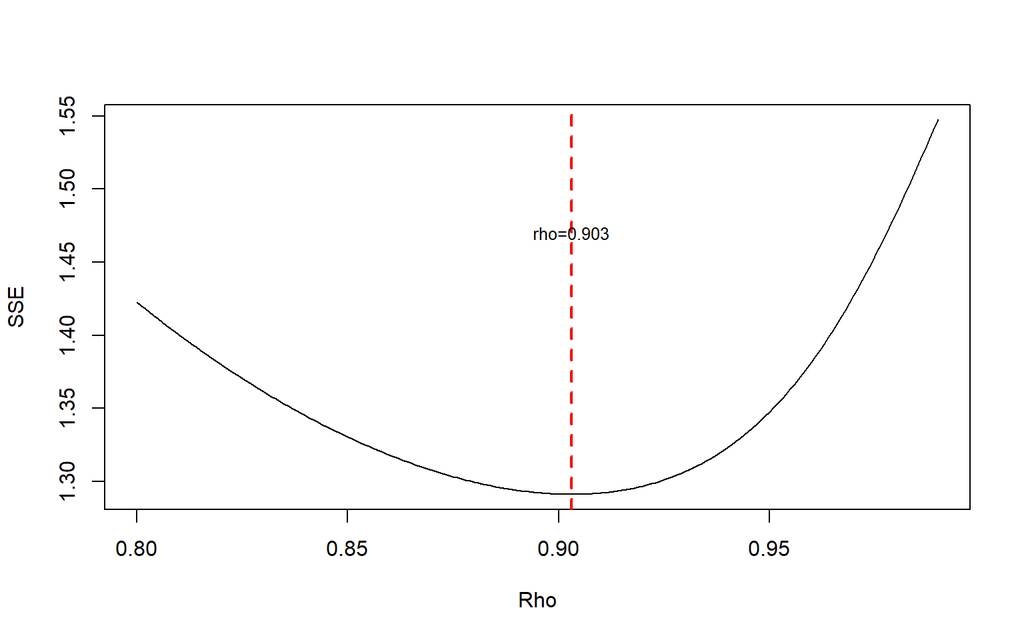

```r
plot(tabOpt2$SSE ~ tabOpt2$rho , type = "l", xlab = "Rho", ylab = "SSE")
abline(v = 0.903, lty = 2, col="red", lwd=2)
text(x=0.903, y=max(tabOpt2$SSE)*0.95, labels = "rho=0.903", cex = 0.8)
```

Nilai $\rho$ optimum $=0.903$, sejalan dengan hasil Cochrane-Orcutt.

```r
modelHL2 <- hildreth.lu.func(0.903, model2)
summary(modelHL2)
```

```
##
## Call:
## lm(formula = y ~ x)
##
## Residuals:
##      Min       1Q   Median       3Q      Max
## -0.37720 -0.14949  0.01266  0.10464  0.45301
##
## Coefficients:
##             Estimate Std. Error t value Pr(>|t|)
## (Intercept)  0.99401    0.14144   7.028 2.60e-08 ***
## x            0.48869    0.07536   6.485 1.39e-07 ***
## ---
## Signif. codes:  0 '***' 0.001 '**' 0.01 '*' 0.05 '.' 0.1 ' ' 1
##
## Residual standard error: 0.1868 on 37 degrees of freedom
## Multiple R-squared:  0.532,  Adjusted R-squared:  0.5193
## F-statistic: 42.05 on 1 and 37 DF,  p-value: 1.39e-07
```

```r
cat("y = ", coef(modelHL2)[1]/(1-0.903), "+", coef(modelHL2)[2], "x", sep = "")
```

```
## y = 10.24749+0.4886925x
```

Model hasil Hildreth-Lu:
$$\hat{y}_i =
10.2475+0.4887x_t$$

```r
dwtest(modelHL2)
```

```
##
##  Durbin-Watson test
##
## data:  modelHL2
## DW = 1.9393, p-value = 0.378
## alternative hypothesis: true autocorrelation is greater than 0
```

DW $\approx 1.9393$ ($1.54 < DW < 2.46$), *p-value* $>0.05$, autokorelasi sudah teratasi.

### Perbandingan SSE

```r
sseModelawal2 <- anova(model2)$`Sum Sq`[-1]
sseModelCO2 <- anova(modelCO2manual)$`Sum Sq`[-1]
sseModelHL2 <- anova(modelHL2)$`Sum Sq`[-1]
akurasi2 <- matrix(c(sseModelawal2, sseModelCO2, sseModelHL2), nrow = 1)
colnames(akurasi2) <- c("Model Awal", "Model Cochrane-Orcutt", "Model Hildreth-Lu")
row.names(akurasi2) <- "SSE"
akurasi2
```

```
##     Model Awal Model Cochrane-Orcutt Model Hildreth-Lu
## SSE   10.55453              1.291225          1.291226
```

SSE model awal ($\approx 10.55453$) jauh lebih besar dibandingkan SSE setelah penanganan CO maupun HL ($\approx 1.29$).

Sama seperti pada data `Market Share-Price`, SSE model Cochrane-Orcutt dan Hildreth-Lu pada data `Sales-Advertising` juga bernilai sangat berdekatan, dengan nilai $\hat\rho$ optimum yang hampir identik (Cochrane-Orcutt: $\hat\rho \approx 0.9031$; Hildreth-Lu: $\hat\rho = 0.903$). Hal ini mengindikasikan bahwa kedua metode konsisten dalam menemukan titik $\rho$ optimum yang meminimumkan SSE meskipun pendekatannya berbeda (Cochrane-Orcutt bersifat iteratif melalui *packages*, sedangkan Hildreth-Lu melakukan pencarian grid $\rho$ secara eksplisit). Dengan hasil yang hampir setara ini, pemilihan metode dapat didasarkan pada kemudahan penerapan, di mana Cochrane-Orcutt lebih praktis digunakan melalui *packages* `orcutt`.

# Kesimpulan